# Lesson 17

Timothy Luna

9/15/2019

# 3B-L2 Epipolar Geometry

## Intro

The last lesson covered how two images with a known calibration could be used to compute depth in the image. This lesson explains *how*.

The previous lesson also discussed *disparity*, which is inversely proportional to depth.

How do we find the disparity? Given point $a$ in an image we have to find it in the other. But it can’t just be *anywhere*, it has to be *constrained to some reasonable locale*.

## Stereo Correspondence Constraints

In general, with two calibrated cameras, we’ve talked about two parallel optical axes where the focus planes are coplanar. In reality they don’t have to be parallel; they can be *verged* where their optic axes converge to some point.

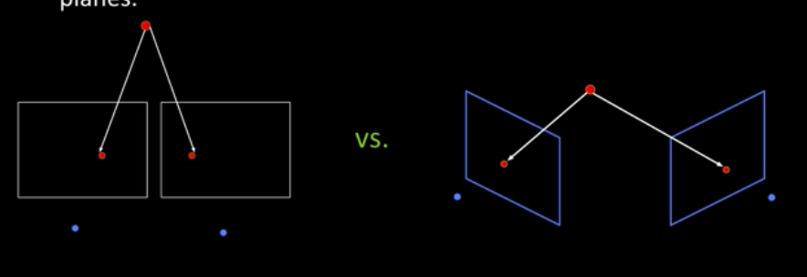

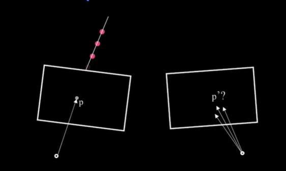

Given an image and some point $p$ with a corresponding calibrated sister image where does the point $p'$ lie? In reality $p$ can lie *anywhere* on the ray that intersects the original image. Remember that in perspective projection lines project into lines.

The line containing the center of projection and the point $p$ in the original image must project to a line in the other image.

## Terms

The geometry of two views constrains where a pixel lies. Point $p$ can be *anywhere* on the line which is projected onto the right image and which is defined by all the possible locatins of $p$. This is called the epipolar line. The epipolar line is the line defined by the planar intersections of the focal plane of the right image and the plane defined by both image centers and the true point $p$. The reverse is also true. That same plane corresponds to the *left* epipolar line.

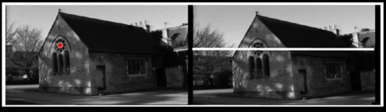

These corresponding set of epipolar lines provide the constraints we’re looking for.

Terms to be familiar with:

- Baseline: Line joining the camera centers.
- Epipolar plane: plane containing the baseline (origins) and the world point $p$.
- Epipolar line: Intersection of epipolar plane with the image planes, and it comes in pairs. A point with a given epipolar line must have a matching point on the corresponding epipolar line.
- Epipole: point of intersection of baseline with the image plane. If the image plane is big enough then the epipole can intersect the image plane. Every epipolar line also intersects the epipoles.

## Epipolar Constraint

Why is the epipolar constraint useful? It reduces the correspondence problem to a 1D search along the epipolar line!

## Converging Cameras

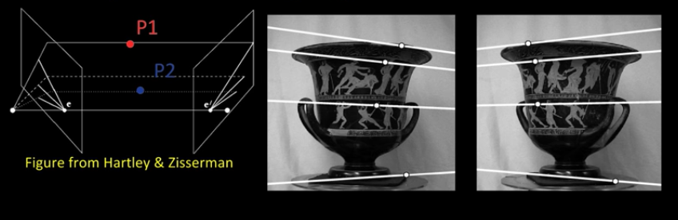

The verged case

All the epipolar lines converge at the epipole, but where is the epipole? Outside the iamge in this case. The image is too small to capture the epipole.

## Parallel Image Planes

Now consider parallel image planes.

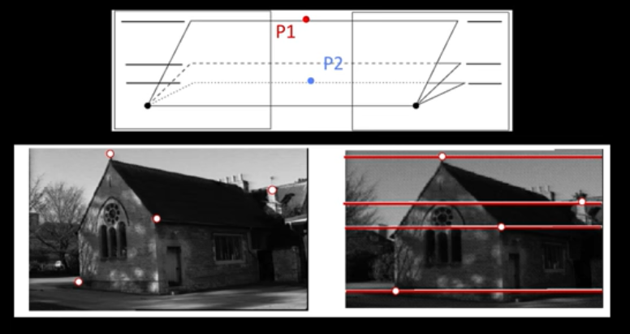

Parallel image planes

Where are the epipoles? Parallel lines intersect at infinity! The epipoles are at infinity.

## Quiz: Two Stereo Pairs

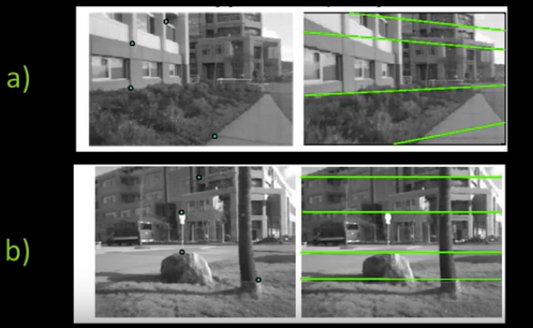

The top image is verged, which is obvious because the lines will intersect. The bottom is from an image pair with parallel optical axes (coplanar image planes.)

How do we *know* that B has parallel image planes?

1. The epipolar lines are horizontal.
2. The Epipolar lines are parallel
3. Because I said so.

The answer is b.

Parallel image planes mean the epipolar lines are parallel, they’re horizontal because of the way the camera was held. The camera could be rotated and still have parallel epipolar lines that are not horizontal.

## End

Next lesson we assume epipolar lines are known. Most will use horizontal parallel lines. We will solve the correspondence problem!